# Week 9 - Assignment

Samriti Malhotra, Vishal Arora

March 31, 2019

# 1 Introduction

As part of week9 assignment , we need to connec to one of the New York Times APIs, construct an interface in R to read in the JSON data, and transform it to an R dataframe. -[NYT API’s home page](https://developer.nytimes.com/apis)

# 2 Problem Statment

Connect to NYT Article search API, and search for keywords “brexit+deal” , and do some analysis.

## 2.1 Solution

Before connecting to NYT Search API, we need to register ourselves and create an account and then need to generate and Key-API which will be passed along with every request for our search of the article on NYT site. -[How to create an account and generate API-KEY on NYT API](https://developer.nytimes.com/get-started).

Libraries used in our solution.  
- RJSONIO  
- RCURL  
- dplyr  
- kableExtra  
- DT

*Step1 :-* connect to NYT article search and use keywords “brexit+deal” to look for only page 1 as search results and also passing the API-KEY to connect to NYT Api’s.  
*Step2 :-* Using getURL function to download the response and then using the fromJSON function from RJSONIO package , we read content in json format and then deserializes to R object.  
*Step3 :-* Using append function to append the output from unlisting till value of docs element in JSON format and append to dat object which is an empty list.  
*Step4 :-* Using as.data.frame object to convert list object dat to Data Frame and using tail to print the last 6 values and dim to print how many observations and variables are present in our data frame object.

```r
api <- "bIdanG9zYkeBTahBbLFfiHpZiBbIqmLz"
q <- "brexit+deal"
dat <- c()
uri=paste0("http://api.nytimes.com/svc/search/v2/articlesearch.json?q=brexit+deal&page=1&api-key=bIdanG9zYkeBTahBbLFfiHpZiBbIqmLz")
d <- getURL(uri)
res <- fromJSON(d,simplify = FALSE)
dat <- append(dat,unlist(res$response$docs))
df <- as.data.frame(table(dat))
kable(tail(df)) %>%
  kable_styling(bootstrap_options = c("striped","condensed","responsive"),full_width   = F,position = "left",font_size = 12) %>%
  row_spec(0, background ="gray")
```

|  | dat | Freq |
| --- | --- | --- |
| 86 | The Latest: UK Speaker: Govt Can’t Present Same Brexit Deal | 2 |
| 87 | The speaker of Britain’s House of Commons dealt a potentially fatal blow to Prime Minister Theresa May’s ailing Brexit deal on Monday, saying the government couldn’t keep asking lawmakers to vote on t… | 2 |
| 88 | UK’s May Urges Lawmakers to Back Her Brexit Deal Now | 2 |
| 89 | UK PM’s May’s Brexit Deal Is ‘Rancid’: Conservative Lawmaker Francois | 2 |
| 90 | UK Speaker Stymies PM May’s Bid for 3rd Vote on Brexit Deal | 2 |
| 91 | World | 9 |

```r
dim(df)
```

```
## [1] 91  2
```

> fl = You can limit the number fields returned in the response with the fl parameter. - [NYT API Docs for parameters](https://developer.nytimes.com/docs/articlesearch-product/1/overview)

```r
records <- 300
pageRange <- 0:(records/10-1)
# get data
dat1 <- c()
for (i in pageRange) {
   # concatenate URL for each page
   uri <- paste0("http://api.nytimes.com/svc/search/v2/articlesearch.json?q=", q, "&page=", i, "&fl=pub_date&api-key=", api)
   d <- getURL(uri)
   res <- fromJSON(d,simplify = FALSE)
   res
   dat1 <- append(dat1, unlist(res$response$docs))

 }
dat1.conv <- strptime(dat1, format="%Y-%m-%d") # need to convert dat into POSIX format
daterange <- c(min(dat1.conv), max(dat1.conv))
dat1.all <- seq(daterange[1], daterange[2], by="day") # all possible days
cts <- as.data.frame(table(dat1))
dat1.all <- strptime(dat1.all, format="%Y-%m-%d")
kable(head(dat1.all,n=10)) %>%
  kable_styling(bootstrap_options = c("striped","hover","condensed","responsive"),full_width   = F,position = "left",font_size = 12) %>%
  row_spec(0, background ="gray")
```

| x |
| --- |
| 2018-11-14 |
| 2018-11-15 |
| 2018-11-16 |
| 2018-11-17 |
| 2018-11-18 |
| 2018-11-19 |
| 2018-11-20 |
| 2018-11-21 |
| 2018-11-22 |
| 2018-11-23 |

```r
freqs <- ifelse(as.character(dat1.all) %in% as.character(strptime(cts$dat1, format="%Y-%m-%d")), cts$Freq, 0)

kable(head(freqs)) %>%
  kable_styling(bootstrap_options = c("striped","hover","condensed","responsive"),full_width   = F,position = "left",font_size = 12) %>%
  row_spec(0, background ="gray")
```

| x |
| --- |
| 1 |
| 2 |
| 1 |
| 0 |
| 1 |
| 0 |

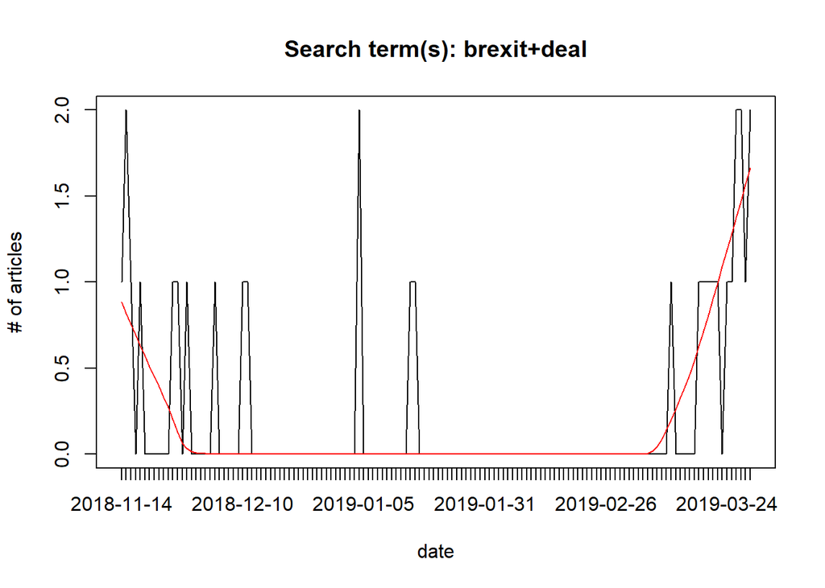

```r
plot.default(freqs, type="l", xaxt="n", main=paste("Search term(s):",q), ylab="# of articles", xlab="date")
axis(1, 1:length(freqs), dat1.all)
lines(lowess(freqs, f=.2), col = 2)
```

# 3 Summary

Looking at the graph, it is clearly visible on what date what is the frequency of articles published in NYT.